# Notebook

```python
import numpy as np
import pandas as pd
```

```python
from pylab import *
import matplotlib.pyplot as plt
from scipy import stats
```

```python
%matplotlib inline
```

```python
def ttest_group(data, by, var):
    g = data.groupby(by)[var]
    keys = g.groups.keys()
    res = pd.DataFrame(data=np.empty(shape=(len(g.groups), 2*len(g.groups))),
                       index=g.groups.keys(),
                       columns=pd.MultiIndex.from_product([['t stat.','p-value'], g.groups.keys()], names=[var, by]),
                       dtype='object')
    #res.index.name = by
    #res.columns.name = by
    for key1 in keys:
        for key2 in keys:
            if key1 == key2:
                res.loc[key1, ('t stat.', key2)] = "x"
                res.loc[key1, ('p-value', key2)] = "x"
            else:
                res.loc[key1, ('t stat.', key2)] = "%0.2f" % stats.ttest_ind(g.get_group(key1), g.get_group(key2))[0]
                res.loc[key1, ('p-value', key2)] = "%0.3f" % stats.ttest_ind(g.get_group(key1), g.get_group(key2))[1]
    return res
```

# Introduction

What defines a *good* or *effective* article on Wikipedia?

But to ask that question, we must also ask: What is the *purpose* of a Wikipedia article? But again, this question forces another: What do people go to Wikipedia *for*? For, if we know why users *use* Wikipedia, it makes sense to then say that the purpose of its articles is to satisfy the needs of the users, and thus an effective article is one which satisfies the needs of those who visit it. (It should be noted, explicitly, of course, that I am here considering the *users* to primarily be those who *read* Wikipedia, rather than those who *edit* it—though of course editors are also users in this sense, just a small proportion of them; if Wikipedia is conceived of as primarily a *community of editors*, a sort of virtual hobby whose purpose is to satisfy the hobbyists, then the above questions become much less significant and, I believe, so does Wikipedia itself.)

I argue that Wikipedia users go to Wikipedia for reasons that, often, could be roughly broken down into 3 categories:

1. *To learn*: a user is curious about a concept, or they are researching an assignment, or they have come across something they don't understand. These users want a brief description of what they are looking for, a sort of long-form definition. Often, such users are not experts in the article's broader field, and thus are looking for a description that is understandable for the layperson:
   - It does not exessively use vocabulary that is not defined or introduced clearly.
   - It does not define the subject of the article solely based upon other concepts with which the user is similarly unfamiliar.
   - It clearly explains not only *what* the subject is, but *why* it is significant in the broader context (an area that, when I have been using Wikipedia in this way, I have found to be lacking).
2. *To find information*: a user is looking for a particular fact or detail—Who is so-and-so married to? When did so-and-so die? When *was* the Battle of Such-and-such? This of course could be seen as a subset of #1 (and in fact so could all uses), but I distinguish it because, in this case, the user *knows what he or she wants to find*. They know that So-and-so is a public figure, they just don't know who So-and-so's spouse is. These users often don't need to read the articles themselves: much of the factual information is summarized in the infoboxes. What is the electronegativity of platinum? Note that such a user would never search for that information if they did not already know:
   - What platinum is
   - What electronegativity is
   - Why one would need to know the electronegativity of an element
3. *To remember what has been forgotten*: a user is refreshing their understanding of a subject. Again, this could be a subset of both #1 and #2, but I distinguish it because, unlike #1, the user is already quite familiar with the material, and unlike #2, the user is looking for something that is not a clear-cut fact which could be listed in an infobox. For example: When do I use a one-tailed t-test vs. a two-tailed one? Where was the epigraph to *The Waste Land* from? How many of Wittgenstein's brothers committed suicide? What was the precipitating event of the Opium Wars? This user will make use of the section headings and perhaps look for a certain phrase in the page, skimming until the information is found. Again, this user knows a fair amount about the subject, as well as how the subject relates to the broader context.

Though all related, these use cases for Wikipedia are, I think, quite distinct, insofar as each will be looking in different parts of the article (e.g. #1 will read the introduction more than #2 or #3 will, #2 will consult the infobox primarily, while the others may ignore it, and #3 may pay close attention to the contents to find the relevant section). Each will also judge the article differently. #1 will likely value clarity of writing, as well as comprehensiveness, but may not have the background to really judge how objective or trustworth an article is (though of course they will notice the extent to which citations are used, etc.). #2 may not read any of the writing, but will notice if key facts are left out. #3 will rely extensively on the article being well organized as well as complete and comprehensive.

Which leads me to: How can (should) we interpret readers' subjective ratings of Wikipedia articles? Can the overall quality of an article be measured by looking at the mean of various readers' ratings? Is there even such a thing as *overall quality* in this context?

1. Are ratings meaningful? Does the rating of one user correlate to the rating of other users?
2. Are the rating dimensions meaningful? Do people actually judge separate components of an article, or do they simply record a sort of binary good/bad, all-1s/all-5s opinion?
3. Do articles get better over time?
4. Does the size (or other measure of magnitude—perhaps reputation of the editor, e.g.) of an edit affect how it changes an article's rating? Does size, for example, improve completeness more than it does trustworthiness or writing quality? Does the number of citations make an article more trustworthy or objective?

## Load data

```python
df = pd.read_csv('cleaned_wiki_ratings.csv')
```

## 1. Ratings per page/Ratings per version

### 1a - Which page has the most ratings?

```python
r = df.groupby('page_title').page_rate_count.max()
r.describe()
```

```
count    10000.000000
mean         7.852400
std         42.055952
min          1.000000
25%          1.000000
50%          2.000000
75%          5.000000
max       2713.000000
Name: page_rate_count, dtype: float64
```

```python
r.sort(ascending=False)
r.head(10)
```

```
page_title
The_Hunger_Games                             2713
List_of_spells_in_Harry_Potter               1685
Abraham_Lincoln                              1389
Marilyn_Monroe                                663
Dhirubhai_Ambani                              596
OSI_model                                     567
Knights_Templar                               553
Arithmetic_progression                        442
United_States_Declaration_of_Independence     439
Business_development                          408
Name: page_rate_count, dtype: int64
```

Ha, the Hunger Games! Not very surprising. Some of the others are interesting, though! (Knights Templar?!)

**NB:** Of course, this is a *sample*, so this does not really say much about the world itself.

Let's look at a plot of the distribution:

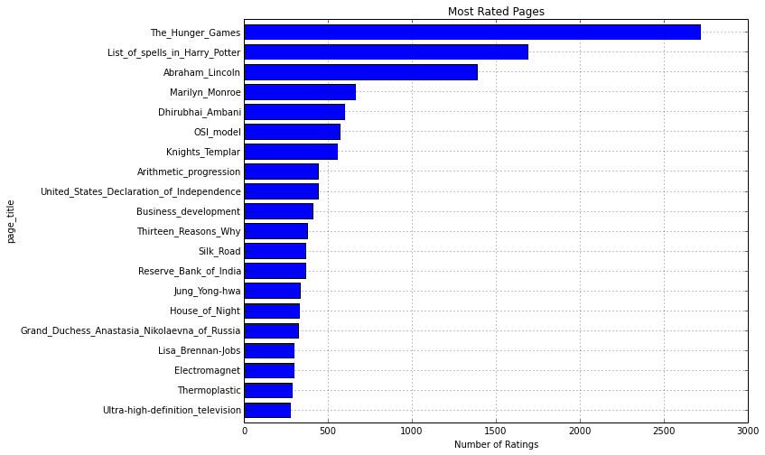

```python
fig = plt.figure()
r.sort() # sort ascending and take the tail so that the top bar on the plot is the highest of the group
ax = r.tail(20).plot(
    kind='barh',
    title='Most Rated Pages',
    figsize=(10, 8))
ax.set_xlabel('Number of Ratings')
```

And let's look at the overall distribution.

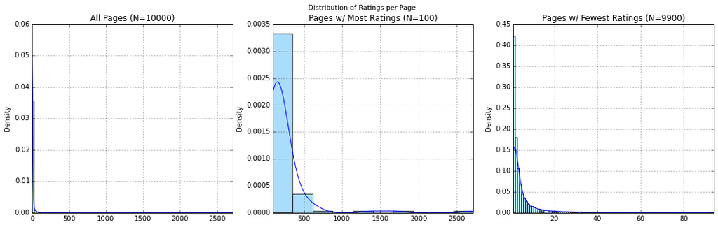

```python
fig, axes = plt.subplots(nrows=1, ncols=3, figsize=(18,5))

for i, section, title in [(0, r, 'All Pages'),
                (1, r.iloc[-100:], 'Pages w/ Most Ratings'),
                (2, r.iloc[0:-100], 'Pages w/ Fewest Ratings')] :
    section.hist(ax=axes[i],
           normed=True,
           bins=math.sqrt(section.count()),
           color='lightskyblue',
           alpha=0.7)
    section.plot(ax=axes[i],
                 kind='kde',
                 xlim=(section.min(), section.max()),
                 title="%s (N=%d)" % (title, section.count()))

fig.suptitle("Distribution of Ratings per Page")
#fig.tight_layout()
```

The right-tadistribution is hardly surprising, though the drop-off is quite sharp, as the most-rated pages tend to be rated many times more than the next-most-rated.

### 1b - Which pages have the most rated versions?

More versions means that we have more rated edits, and thus can trace the article quality over a greater history.

**NB:** I distinguish between "versions" and "rated versions" (or in some cases "versions rated") because I am using data from the ratings dataset only, at this stage. Any versions of the page that don't have any ratings are thus invisible in this dataset; there is no way, for example, to look at the number of edits made to a page, only the number of *edits that have been rated*.

```python
v = df.groupby('page_title').rev_id.unique().apply(lambda x: x.size)
v.describe()
```

```
count    10000.000000
mean         3.661200
std         10.193802
min          1.000000
25%          1.000000
50%          2.000000
75%          3.000000
max        580.000000
dtype: float64
```

```python
v.sort(ascending=False)
v.head(10)
```

```
page_title
The_Hunger_Games                      580
Abraham_Lincoln                       250
Marilyn_Monroe                        169
MDNA_(album)                          157
OSI_model                             145
The_Amazing_Spider-Man_(2012_film)    135
Knights_Templar                       134
House_of_Night                        130
Thirteen_Reasons_Why                  129
Ice_hockey                            124
dtype: int64
```

Some clear similarities with **1a**.

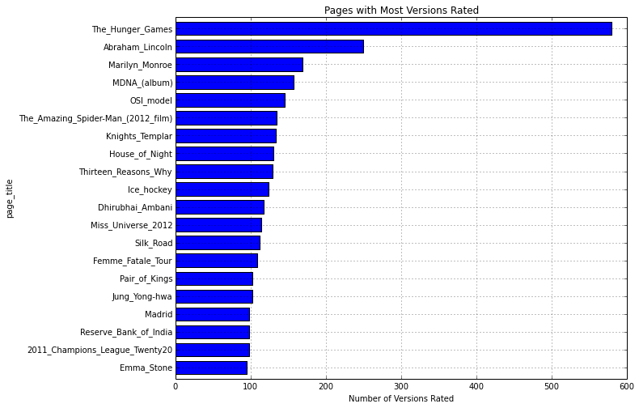

```python
fig = plt.figure()
v.sort()
ax = v.tail(20).plot(
    kind='barh',
    title='Pages with Most Versions Rated',
    figsize=(10, 8))
ax.set_xlabel('Number of Versions Rated')
```

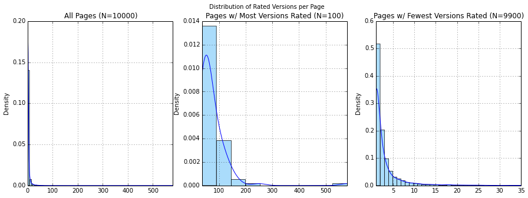

```python
fig, axes = plt.subplots(nrows=1, ncols=3, figsize=(15,5))

for i, section, title in [(0, v, 'All Pages'),
                (1, v.iloc[-100:], 'Pages w/ Most Versions Rated'),
                (2, v.iloc[0:-100], 'Pages w/ Fewest Versions Rated')] :
    section.hist(ax=axes[i],
           normed=True,
           bins=min(math.sqrt(section.count()), len(section.unique())),
           color='lightskyblue',
           alpha=0.7)
    section.plot(ax=axes[i],
                 kind='kde',
                 xlim=(section.min(), section.max()),
                 title="%s (N=%d)" % (title, section.count()))

fig.suptitle("Distribution of Rated Versions per Page")
#fig.tight_layout()
```

### 1c - Ratings Per Version

Ratings per version gives us a measure of the information we have for each version, i.e. how reliable the ratings are.

```python
rpv = r / v
rpv.describe()
```

```
count    10000.000000
mean         1.626829
std          1.403800
min          1.000000
25%          1.000000
50%          1.000000
75%          2.000000
max         40.119048
dtype: float64
```

```python
rpv.sort(ascending=False)
rpv.head(10)
```

```
page_title
List_of_spells_in_Harry_Potter         40.119048
Syn_and_anti_addition                  30.000000
Tool_pusher                            25.000000
Alan_Questel                           23.200000
MS_Contin                              22.500000
Group_technology                       22.000000
Arc_elasticity                         21.000000
The_Other_Side_of_the_Sky:_A_Memoir    20.000000
Cultural_lag                           17.000000
Cultural_institutions                  17.000000
dtype: float64
```

This is interesting! Not what you'd expect. RPV can be conceived as the view velocity divided by the editing velocity, i.e. the number of views per edit (there're a lot of assumptions underlying that conception of course).

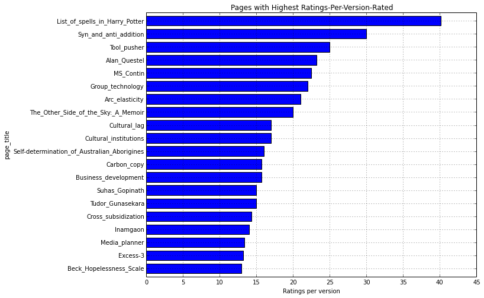

```python
fig = plt.figure()
rpv.sort()
ax = rpv.tail(20).plot(
    kind='barh',
    title='Pages with Highest Ratings-Per-Version-Rated',
    figsize=(10, 8))
ax.set_xlabel('Ratings per version')
```

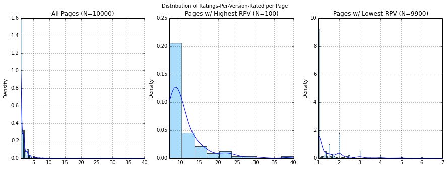

```python
fig, axes = plt.subplots(nrows=1, ncols=3, figsize=(15,5))

for i, section, title in [(0, rpv, 'All Pages'),
                (1, rpv.iloc[-100:], 'Pages w/ Highest RPV'),
                (2, rpv.iloc[0:-100], 'Pages w/ Lowest RPV')] :
    section.hist(ax=axes[i],
           normed=True,
           bins=math.sqrt(section.count()),
           color='lightskyblue',
           alpha=0.7)
    section.plot(ax=axes[i],
                 kind='kde',
                 xlim=(section.min(), section.max()),
                 title="%s (N=%d)" % (title, section.count()))

fig.suptitle("Distribution of Ratings-Per-Version-Rated per Page")
#fig.tight_layout()
```

Note that, because this is a quotient, there are bumps at `p/q`.

## 2. Page Ratings

### 2a - What is the distribution of page ratings?

Let's look at the distribution of all ratings. First we'll look at `ratings_all_mean` (the mean of all dimensions *only when all dimensions are present*, and `ratings_any_mean` (the mean of any dimensions that are present). We'll also look at the number of dimensions rated.

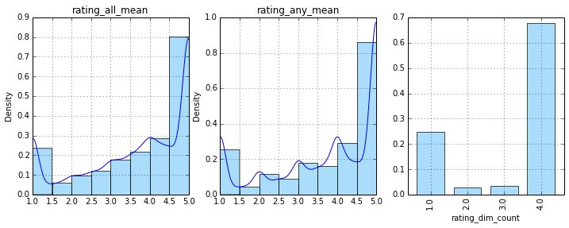

```python
bins = [1,1.5,2,2.5,3,3.5,4,4.5,5]
fig, axes = plt.subplots(nrows=1, ncols=3, figsize=(12, 4))
# Means
for i, var in enumerate(['rating_all_mean', 'rating_any_mean']):
    df[var].dropna().hist(ax=axes[i],
                            normed=True,
                            bins=bins,
                            color='lightskyblue',
                            alpha=0.7)
    df[var].dropna().plot(ax=axes[i],
                            kind='kde',
                            xlim=(1,5),
                            title=var)

# Number of dimensions per rating
dim_counts = df.groupby(['rating_dim_count']).page_id.count() / df.page_id.count()
dim_counts
#if True:
dim_counts.plot(ax=axes[2],
                    kind='bar',
                    color='lightskyblue',
                    alpha=0.7)
```

### 2b What does it mean if a user does not rate all dimensions?

Why would a user only rate one (or two, or three) dimensions? Perhaps they feel they are not qualified to judge one or more aspects of an article. Or, perhaps they only care about particular dimensions; maybe, for example, a user doesn't believe "trustworthiness" is discernable from "objectivity", and thus they only rate one of those. Does the distribution of ratings change based on how many dimensions are rated? For example, perhaps people rate one dimension when they find something particularly egregious, and so they tend to give poor ratings.

Let's look at the distribution of `rating_any_mean` by number of rated dimensions.

| rating_dim_count | count | mean | std | min | 25% | 50% | 75% | max |
| --- | --- | --- | --- | --- | --- | --- | --- | --- |
| 1 | 19535 | 3.841157 | 1.498986 | 1 | 3.000000 | 5 | 5.000000 | 5 |
| 2 | 2124 | 3.436441 | 1.478599 | 1 | 2.000000 | 4 | 5.000000 | 5 |
| 3 | 2775 | 3.531291 | 1.318520 | 1 | 2.666667 | 4 | 4.666667 | 5 |
| 4 | 53303 | 3.658185 | 1.343684 | 1 | 2.750000 | 4 | 5.000000 | 5 |

4 rows × 8 columns

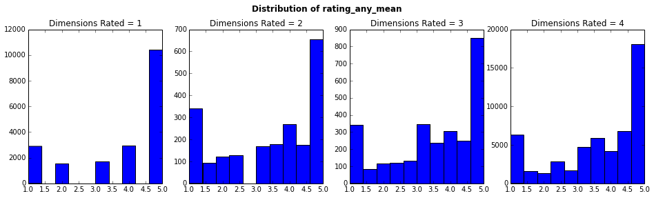

```python
bins = [1,1.5,2,2.5,3,3.5,4,4.5,5]
fig, axes = plt.subplots(nrows=1, ncols=4, figsize=(16, 4))

for i, d in enumerate([1,2,3,4]):
    axes[i].hist(df[df.rating_dim_count==d].rating_any_mean.values, normed=False)
    axes[i].set_title("Dimensions Rated = %d" % d)

fig.suptitle('Distribution of rating_any_mean',
             size='large', weight='bold', va='bottom')

# Output description
df.groupby('rating_dim_count').rating_any_mean.describe().unstack()
```

So it appears that **users who rate only one dimension tend to rate that dimension more highly**. Let's do a t-test to make sure:

```python
ttest_group(df, by='rating_dim_count', var='rating_any_mean')
```

| rating_any_mean rating_dim_count | t stat. 1 | t stat. 2 | t stat. 3 | t stat. 4 | p-value 1 | p-value 2 | p-value 3 | p-value 4 |
| --- | --- | --- | --- | --- | --- | --- | --- | --- |
| 1 | x | 11.83 | 10.34 | 15.77 | x | 0.000 | 0.000 | 0.000 |
| 2 | -11.83 | x | -2.37 | -7.43 | 0.000 | x | 0.018 | 0.000 |
| 3 | -10.34 | 2.37 | x | -4.85 | 0.000 | 0.018 | x | 0.000 |
| 4 | -15.77 | 7.43 | 4.85 | x | 0.000 | 0.000 | 0.000 | x |

4 rows × 8 columns

### 2c - What are the distributions of each dimension?

Now let's look at each particular dimension. Are users more forgiving on some dimensions vs. others?

```python
dims = ['comp', 'obj', 'trust', 'writ']
nonmiss = df.loc[:,dims].count() / len(df)
nonmiss.name = 'pct not missing'
desc = df.loc[:,dims].describe()
pd.concat([pd.DataFrame(count).T, desc]).T
```

|  | pct not missing | count | mean | std | min | 25% | 50% | 75% | max |
| --- | --- | --- | --- | --- | --- | --- | --- | --- | --- |
| comp | 0.767447 | 60263 | 3.400445 | 1.546554 | 1 | 2 | 4 | 5 | 5 |
| obj | 0.732209 | 57496 | 3.713180 | 1.489605 | 1 | 3 | 4 | 5 | 5 |
| trust | 0.789478 | 61993 | 3.719404 | 1.516014 | 1 | 3 | 4 | 5 | 5 |
| writ | 0.835006 | 65568 | 3.813003 | 1.412942 | 1 | 3 | 4 | 5 | 5 |

4 rows × 9 columns

So it appears that **"completeness" tends to be rated lower than other dimensions**, while **"well-written" tends to be rated higher**. Also, **fewer users rate "objectivity", while more users rate "well-written"**.

Let's look at histograms of ratings for each dimension.

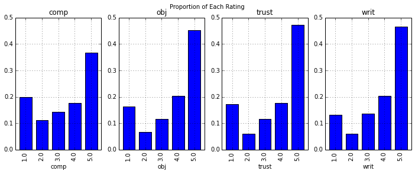

```python
fig, axes = plt.subplots(nrows=1, ncols=4, figsize=(12, 4))

for i, d in enumerate(dims):
    gs = df.groupby([d])
    rtgs = df[d].dropna().count()
    x = gs[d].count() / rtgs
    x.plot(ax = axes[i], kind='bar', ylim=(0,.5))
    axes[i].set_title(d)

fig.suptitle('Proportion of Each Rating')
```

### 2d - How is each dimension related to the others?

Are dimensions correlated? We already know that a lot of users give all `5`s. But perhaps some dimensions are more correlated with others?

```python
for method in ['pearson', 'spearman']:
    print "%s Correlation" % method
    print df[dims].corr(method)
```

```
pearson Correlation
           comp       obj     trust      writ
comp   1.000000  0.715450  0.749500  0.764108
obj    0.715450  1.000000  0.774930  0.738221
trust  0.749500  0.774930  1.000000  0.753312
writ   0.764108  0.738221  0.753312  1.000000

[4 rows x 4 columns]
spearman Correlation
           comp       obj     trust      writ
comp   1.000000  0.704479  0.735459  0.759818
obj    0.704479  1.000000  0.751640  0.703651
trust  0.735459  0.751640  1.000000  0.725299
writ   0.759818  0.703651  0.725299  1.000000

[4 rows x 4 columns]
```

As we might expect, **"objective" is correlated most highly with "trustworthy"**. Perhaps less expected, **"complete" and "well-written" are also more correlated with each other than they are with the other dimensions**. These are both true whether we look at normal Pearson correlation or whether we use Spearman's *rho* rank correlation coefficient. Still, **all dimmensions are highly (positively) correlated with each other**.

### 2e - How consistent are ratings for particular pages/versions?

Ideally, ratings would cluster pretty closely for a particular page, and certainly for a particular version. If ratings are truly meaningful to the community as a whole (vs. to a certain individual or a small group), then users should be able to come to some sort of consensus about the quality of a particular page. We will explore this issue more deeply in section 3 (Page Rating Histories), but here we can look at some general statistics.

We'll start by looking at the distribution of ratings around the mean rating. First, I'll focus on ratings that have all four dimensions, since I suspect that such ratings will be of higher quality (on the assumption that someone rating all four dimensions is more likely to actually *consider* all dimensions -- though of course it is also possible that people who rate the same across the board are actually bringing *less* consideration to the process).

We will also only look at pages with at least 3 ratings, and then pages with at least 50 ratings.

```python
p_ratings = df.groupby('page_title').rating_all_mean
df['page_all_mean'] = p_ratings.transform('mean')
df['page_all_rate_count'] = p_ratings.transform('count')
```

```python
df['diff_page_all_mean'] = df.rating_all_mean - df.page_all_mean
for dim in dims:
    df['diff_page_%s_mean' % dim] = df[dim] - df['page_%s_mean' % dim]
```

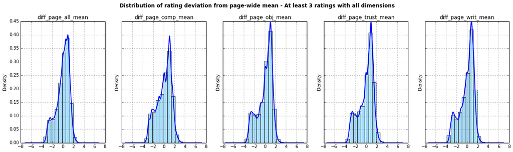

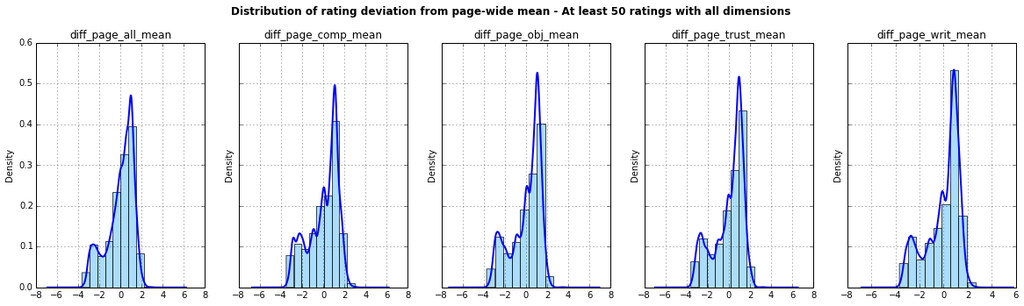

```python
cols = df.filter(like='diff').columns

# At least 3 all ratings
d = df.loc[(df.rating_all_mean.notnull()) & (df.page_all_rate_count >= 3), cols]
fig, axes = plt.subplots(nrows=1, ncols=len(cols), figsize=(4*len(cols), 5), sharey=True)

for i, var in enumerate(cols):
    d[var].dropna().hist(ax=axes[i],
                            normed=True,
                            bins=math.log(d[var].count()),
                            color='lightskyblue',
                            alpha=0.7)
    d[var].dropna().plot(ax=axes[i],
                            kind='kde',
                            linewidth=2,
                            #xlim=(,5),
                            title=var)
fig.suptitle("Distribution of rating deviation from page-wide mean - At least 3 ratings with all dimensions",
             size='large', weight='bold', va='bottom')

# At least 50 all ratings
d = df.loc[(df.rating_all_mean.notnull()) & (df.page_all_rate_count >= 50), cols]
fig2, axes2 = plt.subplots(nrows=1, ncols=len(cols), figsize=(4*len(cols), 5), sharey=True)
for i, var in enumerate(cols):
    d[var].dropna().hist(ax=axes2[i],
                            normed=True,
                            bins=math.log(d[var].count()),
                            color='lightskyblue',
                            alpha=0.7)
    d[var].dropna().plot(ax=axes2[i],
                            kind='kde',
                            linewidth=2,
                            #xlim=(,5),
                            title=var)
fig2.suptitle("Distribution of rating deviation from page-wide mean - At least 50 ratings with all dimensions",
             size='large', weight='bold', va='bottom')
```

### 2f - Do users who are logged in rate pages differently?

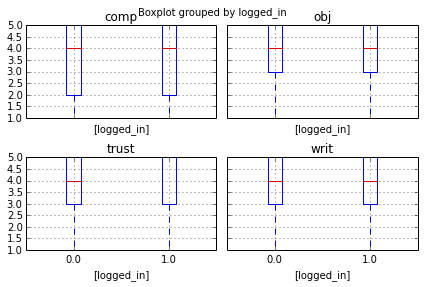

```python
#fig, axes = plt.subplots(nrows=1, ncols=4, figsize=(12, 4))
#fig = plt.figure(figsize=(5,10))
#fig, axes= plt.subplots()
df.boxplot(['comp','obj','trust', 'writ'], by='logged_in')
#fig.tight_layout()
#axes[0].boxplot(df['comp'])
#axes[1].boxplot(df['obj'])
#axes[2].boxplot(df['trust'])
#axes[3].boxplot(df['writ'])
plt.tight_layout()
```

```python
df.plot('comp', by='logged_in', kind='bar')
```

[output not shown]

[output cut: 28 more lines]

[output not shown]

[output not shown]

```
array([[<matplotlib.axes.AxesSubplot object at 0x199a6a410>,
        <matplotlib.axes.AxesSubplot object at 0x19bb36a50>]], dtype=object)
```

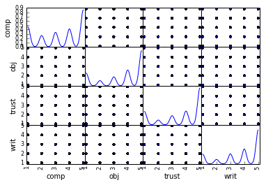

```python
from pandas.tools.plotting import scatter_matrix

scatter_matrix(df[['comp','obj','trust','writ']], diagonal='kde', alpha=0.4)
```

```python
df.groupby(['page_title', 'rev_id'])['comp', 'obj', 'trust', 'writ'].agg(['mean', 'std'])
```

| page_title | rev_id | comp mean | comp std | obj mean | obj std | trust mean | trust std | writ mean | writ std |
| --- | --- | --- | --- | --- | --- | --- | --- | --- | --- |
| .22_Extra_Long | 419871164 | 2.666667 | 1.527525 | 4.666667 | 0.577350 | 3.000000 | 1.000000 | 4.000000 | 0.707107 |
|  | 479583884 | 3.000000 | 2.828427 | 5.000000 | NaN | 5.000000 | NaN | 5.000000 | NaN |
| .30-06_Springfield_Wildcat_Cartridges | 422120131 | NaN | NaN | NaN | NaN | NaN | NaN | 4.333333 | 0.577350 |
|  | 457901474 | 4.000000 | NaN | 5.000000 | NaN | 4.000000 | NaN | 5.000000 | 0.000000 |
|  | 471738565 | 4.000000 | 2.000000 | 4.750000 | 0.500000 | 4.000000 | 0.816497 | 4.500000 | 0.577350 |
|  | 478725666 | 3.500000 | 1.732051 | 4.250000 | 0.957427 | 4.500000 | 0.577350 | 4.000000 | 1.224745 |
| .38_Short_Colt | 438796621 | 2.500000 | 2.121320 | 4.500000 | 0.707107 | 3.000000 | 2.828427 | 3.500000 | 2.121320 |
|  | 464800504 | 1.500000 | 0.707107 | 4.000000 | 1.414214 | 4.000000 | 1.000000 | 4.000000 | 0.000000 |
| .45_Auto_Rim | 415416684 | 1.000000 | NaN | 4.000000 | NaN | 1.000000 | NaN | 4.000000 | NaN |
|  | 442646110 | 3.333333 | 0.577350 | 4.000000 | 1.000000 | 4.000000 | 1.000000 | 4.750000 | 0.500000 |
|  | 479688829 | 2.000000 | NaN | 4.000000 | NaN | 3.000000 | NaN | 2.000000 | NaN |
| .500_S&W_Magnum | 439762470 | 4.000000 | NaN | 5.000000 | NaN | 4.000000 | NaN | 4.000000 | NaN |
|  | 441574061 | 4.500000 | 0.577350 | 4.500000 | 1.000000 | 4.750000 | 0.500000 | 4.600000 | 0.547723 |
|  | 447370819 | 5.000000 | NaN | 5.000000 | NaN | 5.000000 | NaN | 5.000000 | NaN |
|  | 448259671 | 4.000000 | NaN | 5.000000 | NaN | 4.000000 | NaN | 5.000000 | NaN |
|  | 448836686 | 4.000000 | NaN | 5.000000 | NaN | 5.000000 | NaN | 5.000000 | NaN |
|  | 451371481 | 4.000000 | NaN | 2.000000 | NaN | 3.000000 | NaN | 3.000000 | NaN |
|  | 451674936 | 5.000000 | 0.000000 | 4.666667 | 0.577350 | 4.666667 | 0.577350 | 5.000000 | 0.000000 |
|  | 457019107 | 3.500000 | 2.121320 | 1.500000 | 0.707107 | 2.666667 | 2.081666 | 2.500000 | 2.121320 |
|  | 458205328 | 5.000000 | NaN | 4.000000 | NaN | 5.000000 | NaN | 4.000000 | NaN |
|  | 458509665 | 4.500000 | 0.707107 | 4.000000 | 0.000000 | 4.000000 | 1.414214 | 4.500000 | 0.707107 |
|  | 462378207 | 5.000000 | 0.000000 | 4.500000 | 0.707107 | 4.500000 | 0.707107 | 5.000000 | 0.000000 |
|  | 468069156 | 4.000000 | 1.414214 | 3.000000 | 2.828427 | 4.000000 | 1.414214 | 3.500000 | 2.121320 |
|  | 474798489 | 5.000000 | 0.000000 | 5.000000 | 0.000000 | 5.000000 | 0.000000 | 5.000000 | 0.000000 |
|  | 478726535 | 5.000000 | NaN | 5.000000 | NaN | 4.500000 | 0.707107 | 4.000000 | 1.414214 |
|  | 480678815 | 5.000000 | NaN | 5.000000 | 0.000000 | 5.000000 | 0.000000 | 5.000000 | 0.000000 |
|  | 482246318 | 5.000000 | NaN | 2.000000 | NaN | 4.000000 | NaN | 2.000000 | NaN |
|  | 486644437 | NaN | NaN | NaN | NaN | NaN | NaN | 4.000000 | NaN |
|  | 494016595 | 4.500000 | 0.577350 | 4.500000 | 0.577350 | 4.500000 | 0.577350 | 4.750000 | 0.500000 |
| .56-56_Spencer | 409834948 | 5.000000 | NaN | 3.000000 | NaN | 4.000000 | NaN | 4.000000 | NaN |
|  | 474133399 | 3.000000 | 0.000000 | 4.000000 | 0.000000 | 4.000000 | 0.000000 | 4.500000 | 0.707107 |
| .ax | 435858012 | 5.000000 | NaN | 1.000000 | NaN | 5.000000 | NaN | 1.000000 | NaN |
| .detuned | 402623499 | NaN | NaN | NaN | NaN | NaN | NaN | 5.000000 | NaN |
|  | 447003500 | 3.500000 | 2.121320 | 4.000000 | 0.000000 | 4.000000 | 1.414214 | 4.500000 | 0.707107 |
| .pk | 436037238 | 3.500000 | 2.121320 | 5.000000 | NaN | 5.000000 | NaN | 4.000000 | 1.414214 |
| 0898_Beautiful_South | 438303135 | 5.000000 | NaN | NaN | NaN | NaN | NaN | 5.000000 | NaN |
| 1000_Miles_Away | 415188114 | 4.000000 | NaN | 4.000000 | NaN | 3.000000 | NaN | 3.000000 | NaN |
| 100_56_TK | 432944235 | NaN | NaN | NaN | NaN | NaN | NaN | 5.000000 | NaN |
|  | 460672202 | 5.000000 | NaN | 5.000000 | NaN | 5.000000 | NaN | 5.000000 | NaN |
|  | 475175239 | 5.000000 | NaN | 4.000000 | NaN | 5.000000 | NaN | 5.000000 | NaN |
| 100_Demons | 440749170 | 3.000000 | NaN | 5.000000 | NaN | 2.000000 | NaN | 4.000000 | NaN |
|  | 495921797 | 5.000000 | NaN | NaN | NaN | NaN | NaN | NaN | NaN |
| 100th_United_States_Congress | 471842506 | 5.000000 | NaN | NaN | NaN | NaN | NaN | NaN | NaN |
| 1096 | 471746562 | 1.000000 | NaN | 1.000000 | NaN | 1.000000 | NaN | 1.000000 | NaN |
| 10_(LL_Cool_J_album) | 444824666 | 2.000000 | NaN | 3.000000 | NaN | 1.000000 | NaN | 2.000000 | NaN |
|  | 447340854 | 5.000000 | NaN | 5.000000 | NaN | 5.000000 | NaN | 5.000000 | NaN |
|  | 459929449 | 1.000000 | NaN | 5.000000 | NaN | NaN | NaN | NaN | NaN |
| 10_exametres | 439812904 | 5.000000 | NaN | 5.000000 | NaN | 5.000000 | NaN | 5.000000 | NaN |
| 11_Uhr_20 | 459288092 | 1.000000 | NaN | 5.000000 | NaN | 5.000000 | NaN | 5.000000 | NaN |
| 11mm_French_Ordnance | 448894572 | NaN | NaN | NaN | NaN | NaN | NaN | 2.000000 | NaN |
| 11th_British_Academy_Film_Awards | 459774642 | 1.000000 | NaN | 1.000000 | NaN | 1.000000 | NaN | 1.000000 | NaN |
| 128th_Air_Refueling_Wing | 459289344 | 2.000000 | NaN | 3.000000 | NaN | 2.000000 | NaN | 3.000000 | NaN |
| 13_Letters | 432235134 | 2.000000 | NaN | 4.000000 | NaN | 5.000000 | 0.000000 | 5.000000 | NaN |
|  | 442771414 | 5.000000 | NaN | 5.000000 | NaN | 5.000000 | NaN | 5.000000 | NaN |
|  | 445095858 | 4.000000 | 1.414214 | 5.000000 | NaN | 5.000000 | NaN | 5.000000 | 0.000000 |
|  | 449945908 | 5.000000 | 0.000000 | 5.000000 | 0.000000 | 5.000000 | 0.000000 | 4.500000 | 0.707107 |
| 13th_World_Scout_Jamboree | 418945754 | 5.000000 | NaN | 5.000000 | NaN | 5.000000 | NaN | 5.000000 | NaN |
| 1436 | 476776306 | 4.000000 | 0.000000 | 4.000000 | 0.000000 | 4.000000 | 0.000000 | 4.000000 | 0.000000 |
| 1502_in_art | 501905174 | NaN | NaN | NaN | NaN | 4.000000 | NaN | NaN | NaN |
| 1523_in_poetry | 494515499 | NaN | NaN | NaN | NaN | 1.000000 | NaN | NaN | NaN |
|  |  | ... | ... | ... | ... | ... | ... | ... | ... |

36612 rows × 8 columns

## 3. Page Rating History

Before we can look at the page rating history, we need a sense of a "version" that is consistent across pages. The most sensible solution at this point (since we haven't merged in actual revision data from the Wiki DB) is to use *`nth_version`*. Thus, each *rating* can be seen as a piece of information about a particular *version*, with the *versions* themselves being the true "observations".

First we merge in the RPV values for each rating.

```python
df = pd.merge(left=df, right=pd.DataFrame(rpv, columns=['rpv']), left_on='page_title', right_index=True)
df = df.drop('Unnamed: 0', 1)
df.info()
```

```
<class 'pandas.core.frame.DataFrame'>
Int64Index: 78524 entries, 0 to 78523
Data columns (total 24 columns):
rev_id              78524 non-null float64
nth_rating          78524 non-null int64
page_id             78524 non-null int64
page_title          78524 non-null object
logged_in           78524 non-null float64
datetime            78524 non-null object
comp                60263 non-null float64
obj                 57496 non-null float64
trust               61993 non-null float64
writ                65568 non-null float64
rating_dim_count    77737 non-null float64
rating_any_mean     77737 non-null float64
rating_all_mean     53303 non-null float64
page_rate_count     78524 non-null int64
rev_rate_count      78524 non-null float64
page_comp_mean      77283 non-null float64
rev_comp_mean       72232 non-null float64
page_obj_mean       76953 non-null float64
rev_obj_mean        71014 non-null float64
page_trust_mean     77490 non-null float64
rev_trust_mean      72943 non-null float64
page_writ_mean      77450 non-null float64
rev_writ_mean       74095 non-null float64
rpv                 78524 non-null float64
dtypes: float64(19), int64(3), object(2)
```

Now we need to create the `nth_version` variable to index versions.

```python
versions = df[['page_title','rev_id','nth_rating']].groupby(['page_title', 'rev_id']).first().reset_index()
versions['nth_version'] = versions.groupby(['page_title']).cumcount() + 1
```

```python
versions
```

|  | page_title | rev_id | nth_rating | nth_version |
| --- | --- | --- | --- | --- |
| 0 | .22_Extra_Long | 419871164 | 1 | 1 |
| 1 | .22_Extra_Long | 479583884 | 1 | 2 |
| 2 | .30-06_Springfield_Wildcat_Cartridges | 422120131 | 1 | 1 |
| 3 | .30-06_Springfield_Wildcat_Cartridges | 457901474 | 1 | 2 |
| 4 | .30-06_Springfield_Wildcat_Cartridges | 471738565 | 1 | 3 |
| 5 | .30-06_Springfield_Wildcat_Cartridges | 478725666 | 1 | 4 |
| 6 | .38_Short_Colt | 438796621 | 1 | 1 |
| 7 | .38_Short_Colt | 464800504 | 1 | 2 |
| 8 | .45_Auto_Rim | 415416684 | 1 | 1 |
| 9 | .45_Auto_Rim | 442646110 | 1 | 2 |
| 10 | .45_Auto_Rim | 479688829 | 1 | 3 |
| 11 | .500_S&W_Magnum | 439762470 | 1 | 1 |
| 12 | .500_S&W_Magnum | 441574061 | 1 | 2 |
| 13 | .500_S&W_Magnum | 447370819 | 1 | 3 |
| 14 | .500_S&W_Magnum | 448259671 | 1 | 4 |
| 15 | .500_S&W_Magnum | 448836686 | 1 | 5 |
| 16 | .500_S&W_Magnum | 451371481 | 1 | 6 |
| 17 | .500_S&W_Magnum | 451674936 | 1 | 7 |
| 18 | .500_S&W_Magnum | 457019107 | 1 | 8 |
| 19 | .500_S&W_Magnum | 458205328 | 1 | 9 |
| 20 | .500_S&W_Magnum | 458509665 | 1 | 10 |
| 21 | .500_S&W_Magnum | 462378207 | 1 | 11 |
| 22 | .500_S&W_Magnum | 468069156 | 1 | 12 |
| 23 | .500_S&W_Magnum | 474798489 | 1 | 13 |
| 24 | .500_S&W_Magnum | 478726535 | 1 | 14 |
| 25 | .500_S&W_Magnum | 480678815 | 1 | 15 |
| 26 | .500_S&W_Magnum | 482246318 | 1 | 16 |
| 27 | .500_S&W_Magnum | 486644437 | 1 | 17 |
| 28 | .500_S&W_Magnum | 494016595 | 1 | 18 |
| 29 | .56-56_Spencer | 409834948 | 1 | 1 |
| 30 | .56-56_Spencer | 474133399 | 1 | 2 |
| 31 | .ax | 435858012 | 1 | 1 |
| 32 | .detuned | 402623499 | 1 | 1 |
| 33 | .detuned | 447003500 | 1 | 2 |
| 34 | .pk | 436037238 | 1 | 1 |
| 35 | 0898_Beautiful_South | 438303135 | 1 | 1 |
| 36 | 1000_Miles_Away | 415188114 | 1 | 1 |
| 37 | 100_56_TK | 432944235 | 1 | 1 |
| 38 | 100_56_TK | 460672202 | 1 | 2 |
| 39 | 100_56_TK | 475175239 | 1 | 3 |
| 40 | 100_Demons | 440749170 | 1 | 1 |
| 41 | 100_Demons | 495921797 | 1 | 2 |
| 42 | 100th_United_States_Congress | 471842506 | 1 | 1 |
| 43 | 1096 | 471746562 | 1 | 1 |
| 44 | 10_(LL_Cool_J_album) | 444824666 | 1 | 1 |
| 45 | 10_(LL_Cool_J_album) | 447340854 | 1 | 2 |
| 46 | 10_(LL_Cool_J_album) | 459929449 | 1 | 3 |
| 47 | 10_exametres | 439812904 | 1 | 1 |
| 48 | 11_Uhr_20 | 459288092 | 1 | 1 |
| 49 | 11mm_French_Ordnance | 448894572 | 1 | 1 |
| 50 | 11th_British_Academy_Film_Awards | 459774642 | 1 | 1 |
| 51 | 128th_Air_Refueling_Wing | 459289344 | 1 | 1 |
| 52 | 13_Letters | 432235134 | 1 | 1 |
| 53 | 13_Letters | 442771414 | 1 | 2 |
| 54 | 13_Letters | 445095858 | 1 | 3 |
| 55 | 13_Letters | 449945908 | 1 | 4 |
| 56 | 13th_World_Scout_Jamboree | 418945754 | 1 | 1 |
| 57 | 1436 | 476776306 | 1 | 1 |
| 58 | 1502_in_art | 501905174 | 1 | 1 |
| 59 | 1523_in_poetry | 494515499 | 1 | 1 |
|  | ... | ... | ... | ... |

36612 rows × 4 columns

Now merge versions into the main dataframe.

```python
df = pd.merge(left=df, right=versions.drop('nth_rating', 1), left_on=['page_title', 'rev_id'], right_on=['page_title', 'rev_id'])
```

### *Definition of FEFR Sample*

To look more closely at the data, we will examine **frequently edited, frequently rated (FEFR)** pages:

- with at least 5 rated versions (i.e. "revisions" or edits)
- with the highest ratings per rated version

These pages have some amount of history, with a fair amount of information for each version in the history. Note, however, that both the number of *rated versions* (i.e. versions that are in our data) **and** the *ratings per rated version (RPV)* are not necessarily exogenous; in other words, it is quite possible that pages with many versions (and thus many edits), or high RPV, may be different in key and thusfar unobserved ways from other pages. For example, these pages might be more controversial; we can imagine that controversial pages would cause people to rate pages they strongly disagree with *and also* to edit those pages, thus affecting both measures I use to define the sample. However, it is difficult, for example, to have confidence in the mean rating if there are only a handful of ratings for a particular page version. Thus, I'll leave the investigation of how representative these frequently edited, frequently rated pages are of Wikipedia pages in general until a later stage, when I have incorporated data from the Wiki DB itself.

```python
df['page_rev_count'] = df.groupby('page_title').nth_version.transform('max')
```

```python
fe_rpv = df[df.page_rev_count >= 5].groupby('page_title').rpv.first()
fe_rpv.sort(ascending=False)
fefv = df.set_index('page_title').loc[fe_rpv.head(20).index].reset_index()
```

```python
fefv.sort(['page_title', 'nth_version', 'nth_rating'])
fefv.groupby('page_title')[['page_rev_count', 'page_rate_count', 'rpv']].mean()
```

| page_title | page_rev_count | page_rate_count | rpv |
| --- | --- | --- | --- |
| Acidic_oxide | 6 | 53 | 8.833333 |
| Alan_Questel | 5 | 116 | 23.200000 |
| Arithmetic_progression | 40 | 442 | 11.050000 |
| Business_development | 26 | 408 | 15.692308 |
| Carbon_copy | 7 | 110 | 15.714286 |
| Damp_proofing | 10 | 77 | 7.700000 |
| Excess-3 | 5 | 66 | 13.200000 |
| Game_server | 8 | 73 | 9.125000 |
| Homework | 18 | 203 | 11.277778 |
| Implied_powers | 21 | 170 | 8.095238 |
| List_of_spells_in_Harry_Potter | 42 | 1685 | 40.119048 |
| Multitenancy | 7 | 65 | 9.285714 |
| Ornamental_plant | 9 | 77 | 8.555556 |
| Partnership_accounting | 6 | 57 | 9.500000 |
| Pen_pal | 14 | 126 | 9.000000 |
| Pulse_Polio | 10 | 84 | 8.400000 |
| Singaporean_national_referendum,_1962 | 7 | 56 | 8.000000 |
| Ultra-high-definition_television | 35 | 272 | 7.771429 |
| United_States_Declaration_of_Independence | 52 | 439 | 8.442308 |
| Zung_Self-Rating_Anxiety_Scale | 6 | 47 | 7.833333 |

20 rows × 3 columns

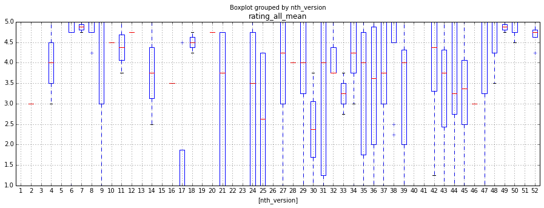

```python
ax = fefv.loc[fefv.page_title=='United_States_Declaration_of_Independence'].boxplot('rating_all_mean', by='nth_version', figsize=(15,5))
```

# TODO

- create boxplots for all 20 FEFV
- restyle boxplots so taht means are more prominent (connected?)
- look into getting edit size

```
---------------------------------------------------------------------------
AttributeError                            Traceback (most recent call last)
<ipython-input-770-608c884cdb6d> in <module>()
      1 fig, axes = plt.subplots(nrows=len(groups), ncols=1, figsize=(15,20))
      2
----> 3 axes[0].add_axes(ax)

AttributeError: 'AxesSubplot' object has no attribute 'add_axes'
```

[figure not shown]

```python
fig, axes = plt.subplots(nrows=len(groups), ncols=1, figsize=(15,20))

axes[0].add_axes(ax)
```

```python
rpv.sort(ascending=False)
rpv.head(20).index
```

```
Index([u'List_of_spells_in_Harry_Potter', u'Syn_and_anti_addition', u'Tool_pusher', u'Alan_Questel', u'MS_Contin', u'Group_technology', u'Arc_elasticity', u'The_Other_Side_of_the_Sky:_A_Memoir', u'Cultural_lag', u'Cultural_institutions', u'Self-determination_of_Australian_Aborigines', u'Carbon_copy'…
```

```python
hrpv = df.set_index('page_title').loc[rpv.head(20).index].reset_index()
```

```python
for i, x, v in enumerate(hrpv.groupby('page_title').groups.items()):
    print(i)
    print(x)
```

```
---------------------------------------------------------------------------
ValueError                                Traceback (most recent call last)
<ipython-input-670-dd5629d29094> in <module>()
----> 1 for i, x, v in enumerate(hrpv.groupby('page_title').groups.items()):
      2     print(i)
      3     print(x)

ValueError: need more than 2 values to unpack
```

```python
pages = hrpv.groupby('page_title')
groups = pages.groups.items()
```

```python
groups[0][0]
```

```
'Media_planner'
```

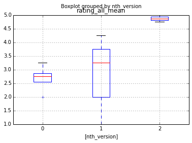

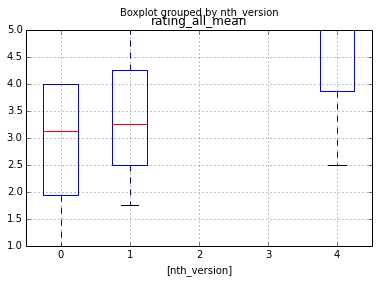

[figure not shown]

```python
#fig, axes = plt.subplots(nrows=len(groups), ncols=1, figsize=(15,20))
#print axes
ax1 = hrpv.loc[groups[0][1]].boxplot(column='rating_all_mean', by='nth_version')
ax2 = hrpv.loc[groups[1][1]].boxplot(column='rating_all_mean', by='nth_version')
fig, axes = plt.subplots(nrows=len(groups), ncols=1, figsize=(15,20))
```

```
Media_planner
Excess-3
Alan_Questel
Tudor_Gunasekara
Cross_subsidization
MS_Contin
Inamgaon
Self-determination_of_Australian_Aborigines
Beck_Hopelessness_Scale
Carbon_copy
Suhas_Gopinath
Business_development
List_of_spells_in_Harry_Potter
Tool_pusher
Syn_and_anti_addition
Cultural_institutions
Group_technology
The_Other_Side_of_the_Sky:_A_Memoir
Arc_elasticity
Cultural_lag
```

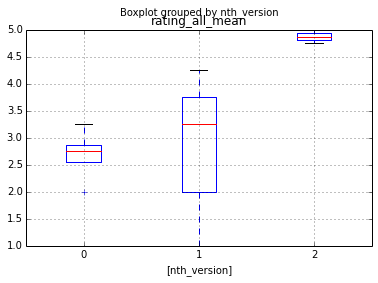

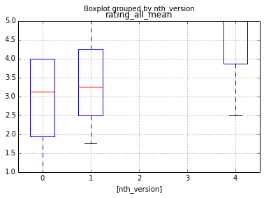

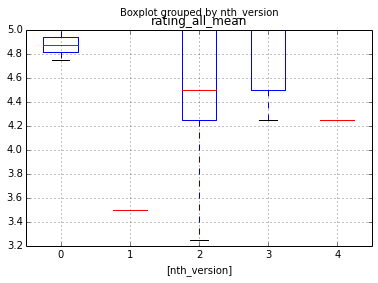

[figure not shown]

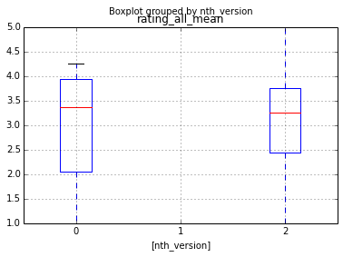

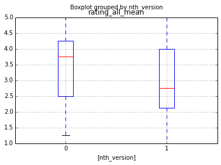

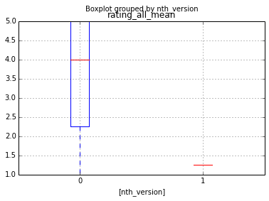

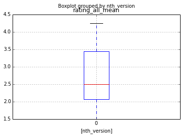

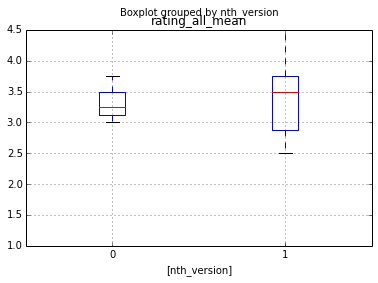

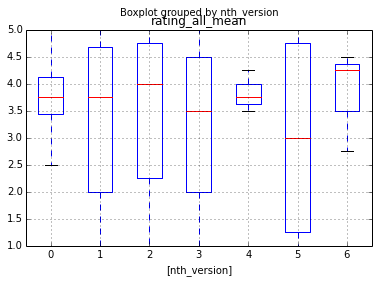

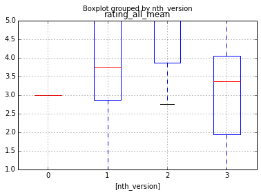

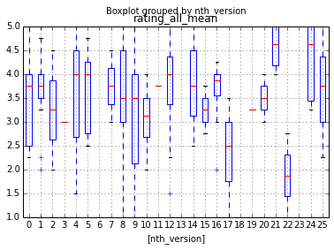

[8 more figures not shown]

```python
for i, g in enumerate(groups):
    #r, c = divmod(i, 4)
    print g[0]
    hrpv.loc[g[1]].boxplot(column='rating_all_mean', by='nth_version')
    #hrpv[hrpv.page_title == g[0]].boxplot(column='rating_all_mean', by=['nth_version'], ax=axes[r, c])
```

```python
hrpv = df.set_index('page_title').loc[rpv.head(20).index]
```

```python
mr = df.set_index('page_title').loc[r.head(20).index].reset_index() # most rated
```

```python
revs = mr.sort(['page_rate_count', 'page_title', 'rev_id', 'datetime']).groupby(['page_title','rev_id'])
```

```python
means = revs.mean().reset_index()
```

```python
means['nth_version'] = means.groupby(['page_title']).rev_id.cumcount() + 1
```

```python
means[['page_title', 'rev_id', 'nth_rating', 'nth_version']].tail(100)
```

|  | page_title | rev_id | nth_rating | nth_version |
| --- | --- | --- | --- | --- |
| 2316 | Thirteen_Reasons_Why | 494230135 | 4.0 | 117 |
| 2317 | Thirteen_Reasons_Why | 496042368 | 1.0 | 118 |
| 2318 | Thirteen_Reasons_Why | 496042514 | 1.0 | 119 |
| 2319 | Thirteen_Reasons_Why | 496042808 | 1.0 | 120 |
| 2320 | Thirteen_Reasons_Why | 496210140 | 1.0 | 121 |
| 2321 | Thirteen_Reasons_Why | 496425242 | 3.0 | 122 |
| 2322 | Thirteen_Reasons_Why | 497718059 | 1.5 | 123 |
| 2323 | Thirteen_Reasons_Why | 497751964 | 2.5 | 124 |
| 2324 | Thirteen_Reasons_Why | 498931832 | 1.5 | 125 |
| 2325 | Thirteen_Reasons_Why | 499094874 | 1.0 | 126 |
| 2326 | Thirteen_Reasons_Why | 499533868 | 2.0 | 127 |
| 2327 | Thirteen_Reasons_Why | 500362094 | 2.0 | 128 |
| 2328 | Thirteen_Reasons_Why | 500908655 | 3.5 | 129 |
| 2329 | Ultra-high-definition_television | 441055808 | 1.0 | 1 |
| 2330 | Ultra-high-definition_television | 442655228 | 4.5 | 2 |
| 2331 | Ultra-high-definition_television | 447052454 | 1.0 | 3 |
| 2332 | Ultra-high-definition_television | 447324961 | 1.0 | 4 |
| 2333 | Ultra-high-definition_television | 447528746 | 1.0 | 5 |
| 2334 | Ultra-high-definition_television | 451449835 | 5.5 | 6 |
| 2335 | Ultra-high-definition_television | 459083961 | 1.0 | 7 |
| 2336 | Ultra-high-definition_television | 459173961 | 2.0 | 8 |
| 2337 | Ultra-high-definition_television | 461109204 | 1.5 | 9 |
| 2338 | Ultra-high-definition_television | 463634856 | 1.0 | 10 |
| 2339 | Ultra-high-definition_television | 463803421 | 1.5 | 11 |
| 2340 | Ultra-high-definition_television | 467078924 | 5.5 | 12 |
| 2341 | Ultra-high-definition_television | 469408903 | 14.5 | 13 |
| 2342 | Ultra-high-definition_television | 470666597 | 1.0 | 14 |
| 2343 | Ultra-high-definition_television | 470812725 | 3.0 | 15 |
| 2344 | Ultra-high-definition_television | 471620680 | 22.0 | 16 |
| 2345 | Ultra-high-definition_television | 472360451 | 20.5 | 17 |
| 2346 | Ultra-high-definition_television | 476065286 | 1.0 | 18 |
| 2347 | Ultra-high-definition_television | 476945490 | 3.5 | 19 |
| 2348 | Ultra-high-definition_television | 477659481 | 7.5 | 20 |
| 2349 | Ultra-high-definition_television | 483271090 | 1.5 | 21 |
| 2350 | Ultra-high-definition_television | 484657965 | 22.5 | 22 |
| 2351 | Ultra-high-definition_television | 486189140 | 1.5 | 23 |
| 2352 | Ultra-high-definition_television | 487213809 | 1.0 | 24 |
| 2353 | Ultra-high-definition_television | 488077624 | 1.5 | 25 |
| 2354 | Ultra-high-definition_television | 489227714 | 1.5 | 26 |
| 2355 | Ultra-high-definition_television | 489423611 | 1.0 | 27 |
| 2356 | Ultra-high-definition_television | 490070071 | 13.0 | 28 |
| 2357 | Ultra-high-definition_television | 493127930 | 1.0 | 29 |
| 2358 | Ultra-high-definition_television | 494807765 | 1.5 | 30 |
| 2359 | Ultra-high-definition_television | 496637115 | 1.5 | 31 |
| 2360 | Ultra-high-definition_television | 496855305 | 1.0 | 32 |
| 2361 | Ultra-high-definition_television | 497432003 | 1.5 | 33 |
| 2362 | Ultra-high-definition_television | 498483715 | 1.0 | 34 |
| 2363 | Ultra-high-definition_television | 498702845 | 3.0 | 35 |
| 2364 | United_States_Declaration_of_Independence | 440924612 | 1.0 | 1 |
| 2365 | United_States_Declaration_of_Independence | 441174192 | 2.0 | 2 |
| 2366 | United_States_Declaration_of_Independence | 442794753 | 1.0 | 3 |
| 2367 | United_States_Declaration_of_Independence | 443013160 | 1.5 | 4 |
| 2368 | United_States_Declaration_of_Independence | 443678194 | 1.0 | 5 |
| 2369 | United_States_Declaration_of_Independence | 444475515 | 3.0 | 6 |
| 2370 | United_States_Declaration_of_Independence | 445183037 | 1.5 | 7 |
| 2371 | United_States_Declaration_of_Independence | 445311436 | 4.0 | 8 |
| 2372 | United_States_Declaration_of_Independence | 447303909 | 2.0 | 9 |
| 2373 | United_States_Declaration_of_Independence | 448533883 | 1.0 | 10 |
| 2374 | United_States_Declaration_of_Independence | 449425041 | 1.5 | 11 |
| 2375 | United_States_Declaration_of_Independence | 449895079 | 1.5 | 12 |
|  | ... | ... | ... | ... |

100 rows × 4 columns

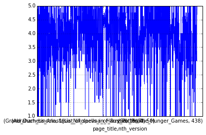

```python
means.set_index(['page_title','nth_version']).rating_all_mean.plot()
```

```python
panel = means.set_index(['page_title', 'nth_version']).to_panel()
```

```python
means
```

|  | page_title | rev_id | Unnamed: 0 | nth_rating | page_id | logged_in | comp | obj | trust | writ | rating_dim_count | rating_any_mean | rating_all_mean | page_rate_count | rev_rate_count | page_comp_mean | rev_comp_mean | page_obj_mean | rev_obj_mean | page_trust_mean |  |
| --- | --- | --- | --- | --- | --- | --- | --- | --- | --- | --- | --- | --- | --- | --- | --- | --- | --- | --- | --- | --- | --- |
| 0 | Abraham_Lincoln | 440005265 | 8475.0 | 1.0 | 307 | 0.000000 | NaN | 1.000000 | NaN | NaN | 1.000000 | 1.000000 | NaN | 1389 | 1 | 3.844368 | NaN | 3.629468 | 1.000000 | 3.757627 | ... |
| 1 | Abraham_Lincoln | 440911206 | 9977.0 | 1.0 | 307 | 0.000000 | 5.000000 | 5.000000 | 5.000000 | 5.000000 | 4.000000 | 5.000000 | 5.000000 | 1389 | 1 | 3.844368 | 5.000000 | 3.629468 | 5.000000 | 3.757627 | ... |
| 2 | Abraham_Lincoln | 441298892 | 10555.0 | 1.0 | 307 | 0.000000 | 1.000000 | 1.000000 | 1.000000 | 1.000000 | 4.000000 | 1.000000 | 1.000000 | 1389 | 1 | 3.844368 | 1.000000 | 3.629468 | 1.000000 | 3.757627 | ... |
| 3 | Abraham_Lincoln | 441456897 | 10838.5 | 2.5 | 307 | 0.000000 | 4.333333 | 4.000000 | 4.333333 | 4.500000 | 3.250000 | 4.000000 | 4.250000 | 1389 | 4 | 3.844368 | 4.333333 | 3.629468 | 4.000000 | 3.757627 | ... |
| 4 | Abraham_Lincoln | 442117130 | 11973.0 | 4.0 | 307 | 0.000000 | 5.000000 | 4.000000 | 5.000000 | 4.800000 | 1.857143 | 4.285714 | 5.000000 | 1389 | 7 | 3.844368 | 5.000000 | 3.629468 | 4.000000 | 3.757627 | ... |
| 5 | Abraham_Lincoln | 442609796 | 12830.5 | 1.5 | 307 | 0.000000 | NaN | 1.000000 | NaN | 5.000000 | 1.000000 | 3.000000 | NaN | 1389 | 2 | 3.844368 | NaN | 3.629468 | 1.000000 | 3.757627 | ... |
| 6 | Abraham_Lincoln | 442784515 | 13148.0 | 2.0 | 307 | 0.000000 | 4.333333 | 3.333333 | 4.000000 | 4.500000 | 3.666667 | 3.666667 | 4.000000 | 1389 | 3 | 3.844368 | 4.333333 | 3.629468 | 3.333333 | 3.757627 | ... |
| 7 | Abraham_Lincoln | 443019560 | 13448.0 | 2.0 | 307 | 0.000000 | 5.000000 | 4.500000 | 5.000000 | 5.000000 | 3.666667 | 4.666667 | 4.875000 | 1389 | 3 | 3.844368 | 5.000000 | 3.629468 | 4.500000 | 3.757627 | ... |
| 8 | Abraham_Lincoln | 443139975 | 13606.0 | 1.0 | 307 | 0.000000 | NaN | NaN | 5.000000 | NaN | 1.000000 | 5.000000 | NaN | 1389 | 1 | 3.844368 | NaN | 3.629468 | NaN | 3.757627 | ... |
| 9 | Abraham_Lincoln | 443407586 | 14024.0 | 16.0 | 307 | 0.000000 | 4.307692 | 3.200000 | 3.625000 | 5.000000 | 1.413793 | 3.448276 | 4.812500 | 1389 | 31 | 3.844368 | 4.307692 | 3.629468 | 3.200000 | 3.757627 | ... |
| 10 | Abraham_Lincoln | 443712151 | 14505.0 | 5.0 | 307 | 0.000000 | 3.375000 | 3.125000 | 3.750000 | 3.375000 | 4.000000 | 3.125000 | 3.406250 | 1389 | 9 | 3.844368 | 3.375000 | 3.629468 | 3.125000 | 3.757627 | ... |
| 11 | Abraham_Lincoln | 444451071 | 15621.5 | 1.5 | 307 | 0.000000 | 4.500000 | 4.000000 | 4.500000 | 4.500000 | 4.000000 | 4.000000 | 4.375000 | 1389 | 2 | 3.844368 | 4.500000 | 3.629468 | 4.000000 | 3.757627 | ... |
| 12 | Abraham_Lincoln | 444614959 | 15744.0 | 1.0 | 307 | 0.000000 | 1.000000 | 1.000000 | 1.000000 | 1.000000 | 4.000000 | 1.000000 | 1.000000 | 1389 | 1 | 3.844368 | 1.000000 | 3.629468 | 1.000000 | 3.757627 | ... |
| 13 | Abraham_Lincoln | 444674141 | 15793.5 | 1.5 | 307 | 0.500000 | 3.000000 | 3.000000 | 4.000000 | 3.000000 | 2.500000 | 3.500000 | 2.750000 | 1389 | 2 | 3.844368 | 3.000000 | 3.629468 | 3.000000 | 3.757627 | ... |
| 14 | Abraham_Lincoln | 445429446 | 16709.0 | 3.0 | 307 | 0.000000 | 4.200000 | 4.000000 | 4.200000 | 4.200000 | 4.000000 | 4.000000 | 4.150000 | 1389 | 5 | 3.844368 | 4.200000 | 3.629468 | 4.000000 | 3.757627 | ... |
| 15 | Abraham_Lincoln | 445730294 | 17238.0 | 1.0 | 307 | 0.000000 | 5.000000 | 5.000000 | 5.000000 | 5.000000 | 4.000000 | 5.000000 | 5.000000 | 1389 | 1 | 3.844368 | 5.000000 | 3.629468 | 5.000000 | 3.757627 | ... |
| 16 | Abraham_Lincoln | 445768245 | 17290.5 | 1.5 | 307 | 0.000000 | NaN | 1.000000 | NaN | 5.000000 | 1.000000 | 3.000000 | NaN | 1389 | 2 | 3.844368 | NaN | 3.629468 | 1.000000 | 3.757627 | ... |
| 17 | Abraham_Lincoln | 445885331 | 17439.0 | 2.0 | 307 | 0.000000 | 4.333333 | 3.666667 | 4.333333 | 4.000000 | 4.000000 | 4.000000 | 4.083333 | 1389 | 3 | 3.844368 | 4.333333 | 3.629468 | 3.666667 | 3.757627 | ... |
| 18 | Abraham_Lincoln | 446194936 | 17811.5 | 1.5 | 307 | 0.000000 | 5.000000 | 5.000000 | 5.000000 | 5.000000 | 2.500000 | 5.000000 | 5.000000 | 1389 | 2 | 3.844368 | 5.000000 | 3.629468 | 5.000000 | 3.757627 | ... |
| 19 | Abraham_Lincoln | 446508142 | 18312.0 | 3.0 | 307 | 0.000000 | 4.250000 | 4.000000 | 4.500000 | 4.250000 | 3.400000 | 3.800000 | 4.375000 | 1389 | 5 | 3.844368 | 4.250000 | 3.629468 | 4.000000 | 3.757627 | ... |
| 20 | Abraham_Lincoln | 446758896 | 18631.0 | 1.0 | 307 | 1.000000 | 2.000000 | 3.000000 | 3.000000 | 1.000000 | 4.000000 | 2.000000 | 2.250000 | 1389 | 1 | 3.844368 | 2.000000 | 3.629468 | 3.000000 | 3.757627 | ... |
| 21 | Abraham_Lincoln | 446870855 | 18789.0 | 15.0 | 307 | 0.000000 | 4.125000 | 3.863636 | 3.842105 | 3.933333 | 3.076923 | 3.884615 | 4.083333 | 1389 | 29 | 3.844368 | 4.125000 | 3.629468 | 3.863636 | 3.757627 | ... |
| 22 | Abraham_Lincoln | 447807518 | 19955.0 | 1.0 | 307 | 0.000000 | 5.000000 | 5.000000 | 5.000000 | 5.000000 | 4.000000 | 5.000000 | 5.000000 | 1389 | 1 | 3.844368 | 5.000000 | 3.629468 | 5.000000 | 3.757627 | ... |
| 23 | Abraham_Lincoln | 448307572 | 20522.0 | 1.0 | 307 | 0.000000 | 1.000000 | 1.000000 | 1.000000 | 1.000000 | 4.000000 | 1.000000 | 1.000000 | 1389 | 1 | 3.844368 | 1.000000 | 3.629468 | 1.000000 | 3.757627 | ... |
| 24 | Abraham_Lincoln | 448771949 | 21006.0 | 1.0 | 307 | 0.000000 | 5.000000 | 5.000000 | 5.000000 | 5.000000 | 4.000000 | 5.000000 | 5.000000 | 1389 | 1 | 3.844368 | 5.000000 | 3.629468 | 5.000000 | 3.757627 | ... |
| 25 | Abraham_Lincoln | 448807845 | 21077.0 | 1.0 | 307 | 0.000000 | NaN | NaN | 5.000000 | NaN | 1.000000 | 5.000000 | NaN | 1389 | 1 | 3.844368 | NaN | 3.629468 | NaN | 3.757627 | ... |
| 26 | Abraham_Lincoln | 448855342 | 21141.0 | 1.0 | 307 | 0.000000 | 2.000000 | 3.000000 | 4.000000 | 2.000000 | 4.000000 | 2.000000 | 2.750000 | 1389 | 1 | 3.844368 | 2.000000 | 3.629468 | 3.000000 | 3.757627 | ... |
| 27 | Abraham_Lincoln | 448965474 | 21338.5 | 9.5 | 307 | 0.000000 | 3.533333 | 3.461538 | 3.714286 | 3.687500 | 3.411765 | 3.647059 | 3.442308 | 1389 | 18 | 3.844368 | 3.533333 | 3.629468 | 3.461538 | 3.757627 | ... |
| 28 | Abraham_Lincoln | 450119851 | 22522.0 | 10.0 | 307 | 0.052632 | 3.312500 | 3.266667 | 3.062500 | 3.687500 | 3.500000 | 3.055556 | 3.366667 | 1389 | 19 | 3.844368 | 3.312500 | 3.629468 | 3.266667 | 3.757627 | ... |
| 29 | Abraham_Lincoln | 450722441 | 23394.0 | 1.0 | 307 | 0.000000 | 5.000000 | NaN | NaN | NaN | 1.000000 | 5.000000 | NaN | 1389 | 1 | 3.844368 | 5.000000 | 3.629468 | NaN | 3.757627 | ... |
| 30 | Abraham_Lincoln | 450833548 | 23553.0 | 2.0 | 307 | 0.000000 | 3.333333 | 3.666667 | 4.333333 | 4.666667 | 4.000000 | 3.666667 | 4.000000 | 1389 | 3 | 3.844368 | 3.333333 | 3.629468 | 3.666667 | 3.757627 | ... |
| 31 | Abraham_Lincoln | 451027539 | 23841.0 | 1.0 | 307 | 0.000000 | NaN | NaN | NaN | 5.000000 | 1.000000 | 5.000000 | NaN | 1389 | 1 | 3.844368 | NaN | 3.629468 | NaN | 3.757627 | ... |
| 32 | Abraham_Lincoln | 451081797 | 23911.0 | 1.0 | 307 | 0.000000 | 5.000000 | 4.000000 | 2.000000 | 2.000000 | 4.000000 | 3.000000 | 3.250000 | 1389 | 1 | 3.844368 | 5.000000 | 3.629468 | 4.000000 | 3.757627 | ... |
| 33 | Abraham_Lincoln | 451242393 | 24137.5 | 3.5 | 307 | 0.000000 | 4.750000 | 4.500000 | 5.000000 | 4.600000 | 3.000000 | 4.666667 | 4.687500 | 1389 | 6 | 3.844368 | 4.750000 | 3.629468 | 4.500000 | 3.757627 | ... |
| 34 | Abraham_Lincoln | 451688282 | 24748.0 | 4.0 | 307 | 0.000000 | 4.500000 | 4.000000 | 4.166667 | 4.142857 | 3.571429 | 3.571429 | 4.291667 | 1389 | 7 | 3.844368 | 4.500000 | 3.629468 | 4.000000 | 3.757627 | ... |
| 35 | Abraham_Lincoln | 451926641 | 25144.5 | 3.5 | 307 | 0.000000 | 3.666667 | 3.833333 | 3.666667 | 3.666667 | 4.000000 | 3.666667 | 3.708333 | 1389 | 6 | 3.844368 | 3.666667 | 3.629468 | 3.833333 | 3.757627 | ... |
| 36 | Abraham_Lincoln | 452234404 | 25499.5 | 1.5 | 307 | 0.000000 | 2.500000 | 2.500000 | 3.000000 | 3.000000 | 4.000000 | 2.500000 | 2.750000 | 1389 | 2 | 3.844368 | 2.500000 | 3.629468 | 2.500000 | 3.757627 | ... |
| 37 | Abraham_Lincoln | 452418621 | 25719.0 | 7.0 | 307 | 0.000000 | 3.916667 | 3.384615 | 3.615385 | 3.583333 | 3.846154 | 3.307692 | 3.729167 | 1389 | 13 | 3.844368 | 3.916667 | 3.629468 | 3.384615 | 3.757627 | ... |
| 38 | Abraham_Lincoln | 452878548 | 26305.5 | 1.5 | 307 | 0.000000 | 3.000000 | 3.000000 | 5.000000 | 5.000000 | 4.000000 | 4.000000 | 4.000000 | 1389 | 2 | 3.844368 | 3.000000 | 3.629468 | 3.000000 | 3.757627 | ... |
| 39 | Abraham_Lincoln | 453300253 | 26878.0 | 2.0 | 307 | 0.000000 | 5.000000 | 5.000000 | 5.000000 | 5.000000 | 3.000000 | 5.000000 | 5.000000 | 1389 | 3 | 3.844368 | 5.000000 | 3.629468 | 5.000000 | 3.757627 | ... |
| 40 | Abraham_Lincoln | 453400516 | 26956.5 | 2.5 | 307 | 0.000000 | 5.000000 | 4.333333 | 4.666667 | 4.750000 | 3.500000 | 4.500000 | 4.666667 | 1389 | 4 | 3.844368 | 5.000000 | 3.629468 | 4.333333 | 3.757627 | ... |
| 41 | Abraham_Lincoln | 453634602 | 27258.5 | 7.5 | 307 | 0.000000 | 3.250000 | 2.916667 | 3.333333 | 2.928571 | 3.571429 | 3.214286 | 3.020833 | 1389 | 14 | 3.844368 | 3.250000 | 3.629468 | 2.916667 | 3.757627 | ... |
| 42 | Abraham_Lincoln | 454075796 | 27869.5 | 1.5 | 307 | 0.000000 | 3.000000 | 1.500000 | 2.500000 | 3.500000 | 4.000000 | 2.000000 | 2.625000 | 1389 | 2 | 3.844368 | 3.000000 | 3.629468 | 1.500000 | 3.757627 | ... |
| 43 | Abraham_Lincoln | 454144929 | 27938.0 | 1.0 | 307 | 0.000000 | 4.000000 | 2.000000 | NaN | 4.000000 | 3.000000 | 3.000000 | NaN | 1389 | 1 | 3.844368 | 4.000000 | 3.629468 | 2.000000 | 3.757627 | ... |
| 44 | Abraham_Lincoln | 454149306 | 27940.0 | 1.0 | 307 | 0.000000 | 5.000000 | 5.000000 | 5.000000 | 5.000000 | 4.000000 | 5.000000 | 5.000000 | 1389 | 1 | 3.844368 | 5.000000 | 3.629468 | 5.000000 | 3.757627 | ... |
| 45 | Abraham_Lincoln | 454245260 | 28078.5 | 1.5 | 307 | 0.000000 | 2.500000 | 3.000000 | 2.500000 | 3.000000 | 4.000000 | 2.500000 | 2.750000 | 1389 | 2 | 3.844368 | 2.500000 | 3.629468 | 3.000000 | 3.757627 | ... |
| 46 | Abraham_Lincoln | 454478141 | 28439.0 | 1.0 | 307 | 1.000000 | 4.000000 | 4.000000 | 5.000000 | 4.000000 | 4.000000 | 4.000000 | 4.250000 | 1389 | 1 | 3.844368 | 4.000000 | 3.629468 | 4.000000 | 3.757627 | ... |
| 47 | Abraham_Lincoln | 454480143 | 28441.5 | 1.5 | 307 | 0.000000 | 4.000000 | 3.000000 | 4.000000 | 5.000000 | 2.500000 | 4.000000 | 3.750000 | 1389 | 2 | 3.844368 | 4.000000 | 3.629468 | 3.000000 | 3.757627 | ... |
| 48 | Abraham_Lincoln | 454634500 | 28613.5 | 1.5 | 307 | 0.000000 | 4.000000 | 5.000000 | 5.000000 | 4.000000 | 2.500000 | 4.000000 | 4.500000 | 1389 | 2 | 3.844368 | 4.000000 | 3.629468 | 5.000000 | 3.757627 | ... |
| 49 | Abraham_Lincoln | 454790083 | 28856.0 | 1.0 | 307 | 0.000000 | 5.000000 | 5.000000 | 5.000000 | 5.000000 | 4.000000 | 5.000000 | 5.000000 | 1389 | 1 | 3.844368 | 5.000000 | 3.629468 | 5.000000 | 3.757627 | ... |
| 50 | Abraham_Lincoln | 454793015 | 28858.5 | 1.5 | 307 | 0.000000 | 4.000000 | 5.000000 | 5.000000 | 5.000000 | 4.000000 | 4.500000 | 4.750000 | 1389 | 2 | 3.844368 | 4.000000 | 3.629468 | 5.000000 | 3.757627 | ... |
| 51 | Abraham_Lincoln | 454810152 | 28871.5 | 1.5 | 307 | 0.000000 | 4.500000 | 4.500000 | 5.000000 | 4.500000 | 4.000000 | 4.500000 | 4.625000 | 1389 | 2 | 3.844368 | 4.500000 | 3.629468 | 4.500000 | 3.757627 | ... |
| 52 | Abraham_Lincoln | 454887804 | 28967.0 | 1.0 | 307 | 0.000000 | 4.000000 | 5.000000 | 1.000000 | 4.000000 | 4.000000 | 3.000000 | 3.500000 | 1389 | 1 | 3.844368 | 4.000000 | 3.629468 | 5.000000 | 3.757627 | ... |
| 53 | Abraham_Lincoln | 454918408 | 28991.0 | 1.0 | 307 | 1.000000 | 1.000000 | 1.000000 | 1.000000 | 1.000000 | 4.000000 | 1.000000 | 1.000000 | 1389 | 1 | 3.844368 | 1.000000 | 3.629468 | 1.000000 | 3.757627 | ... |
| 54 | Abraham_Lincoln | 454980356 | 29077.0 | 1.0 | 307 | 0.000000 | NaN | NaN | NaN | 5.000000 | 1.000000 | 5.000000 | NaN | 1389 | 1 | 3.844368 | NaN | 3.629468 | NaN | 3.757627 | ... |
| 55 | Abraham_Lincoln | 455044325 | 29164.0 | 1.0 | 307 | 0.000000 | 5.000000 | 5.000000 | 5.000000 | 5.000000 | 4.000000 | 5.000000 | 5.000000 | 1389 | 1 | 3.844368 | 5.000000 | 3.629468 | 5.000000 | 3.757627 | ... |
| 56 | Abraham_Lincoln | 455113920 | 29233.0 | 1.0 | 307 | 0.000000 | 5.000000 | 5.000000 | 5.000000 | 5.000000 | 4.000000 | 5.000000 | 5.000000 | 1389 | 1 | 3.844368 | 5.000000 | 3.629468 | 5.000000 | 3.757627 | ... |
| 57 | Abraham_Lincoln | 455202112 | 29315.0 | 1.0 | 307 | 0.000000 | NaN | NaN | NaN | 1.000000 | 1.000000 | 1.000000 | NaN | 1389 | 1 | 3.844368 | NaN | 3.629468 | NaN | 3.757627 | ... |
| 58 | Abraham_Lincoln | 455248046 | 29357.0 | 1.0 | 307 | 0.000000 | 5.000000 | 5.000000 | 5.000000 | 5.000000 | 4.000000 | 5.000000 | 5.000000 | 1389 | 1 | 3.844368 | 5.000000 | 3.629468 | 5.000000 | 3.757627 | ... |
| 59 | Abraham_Lincoln | 455318372 | 29499.5 | 2.5 | 307 | 0.000000 | 4.750000 | 5.000000 | 4.250000 | 5.000000 | 4.000000 | 4.500000 | 4.750000 | 1389 | 4 | 3.844368 | 4.750000 | 3.629468 | 5.000000 | 3.757627 | ... |
|  | ... | ... | ... | ... | ... | ... | ... | ... | ... | ... | ... | ... | ... | ... | ... | ... | ... | ... | ... | ... |  |

2416 rows × 24 columns